# week1_Project

```python
#Importing pandas library
import pandas as pd

# 1. Load the dataset
df = pd.read_csv('../data/online_retail.csv', encoding='ISO-8859-1')

# 2. Display the first few rows
print(df.head())

# 3. Display number of rows and columns
print(f"Dataset Shape: {df.shape}")

# 4. Display column names and basic data types
print(df.info())
```

```
  Invoice StockCode                          Description  Quantity  \
0  489434     85048  15CM CHRISTMAS GLASS BALL 20 LIGHTS        12
1  489434    79323P                   PINK CHERRY LIGHTS        12
2  489434    79323W                  WHITE CHERRY LIGHTS        12
3  489434     22041         RECORD FRAME 7" SINGLE SIZE         48
4  489434     21232       STRAWBERRY CERAMIC TRINKET BOX        24

        InvoiceDate  Price  Customer ID         Country
0  01/12/2009 07:45   6.95      13085.0  United Kingdom
1  01/12/2009 07:45   6.75      13085.0  United Kingdom
2  01/12/2009 07:45   6.75      13085.0  United Kingdom
3  01/12/2009 07:45   2.10      13085.0  United Kingdom
4  01/12/2009 07:45   1.25      13085.0  United Kingdom
Dataset Shape: (525461, 8)
<class 'pandas.core.frame.DataFrame'>
RangeIndex: 525461 entries, 0 to 525460
Data columns (total 8 columns):
 #   Column       Non-Null Count   Dtype
---  ------       --------------   -----
 0   Invoice      525461 non-null  object
 1   StockCode    525461 non-null  object
 2   Description  522533 non-null  object
 3   Quantity     525461 non-null  int64
 4   InvoiceDate  525461 non-null  object
 5   Price        525461 non-null  float64
 6   Customer ID  417534 non-null  float64
 7   Country      525461 non-null  object
dtypes: float64(2), int64(1), object(5)
memory usage: 32.1+ MB
None
```

Task 1 — Written Explanation

What a single row represents: An invoice line item found in real-world business operations. The document presents a particular product item that was purchased but it lacks information about the entire transaction. The database will create five distinct entries for a customer who purchases five different items during a single shopping visit.

Invoice ID: Multiple rows share the same Invoice number because they belong to the same "basket" or transaction. It shows that those different products were all bought at the same time by the same person.

Customer ID: Multiple rows share the same Customer ID because a customer may have multiple items in one basket, and they may also return to the store to make entirely new purchases on different dates.

Task 2 — Define the Unit of Analysis

In this task, I evaluate three different ways to structure the data for analysis. The appropriate unit of analysis must be selected because it defines the patterns that machine learning models will detect.

1. Invoice Line (Row Level): The dataset currently displays its complete contents because each invoice field contains one product. The system preserves complete product information through StockCode and unit price details which enable users to track their shopping patterns. The complete understanding of a business transaction becomes unreachable because of this information loss. The system requires manual row grouping to determine the total shopping value and to track customer behavior patterns over time.
2. Invoice / Basket (Aggregated by Invoice): The data analysis process achieves its objective because each shopping trip gets represented through the Invoice-based data grouping method. The system provides two types of data which include "Basket Size" that measures items per trip and "Total Invoice Value" which shows overall purchases. The system provides excellent performance assessment tools which enable users to evaluate store operations throughout various time periods which include daily and hourly schedules. The specific product details become inaccessible through this method. The basket cost of £100 becomes known to us yet we lose the ability to determine whether the £100 value originated from one expensive item or from fifty inexpensive items.
3. Customer (Aggregated across all Invoices) The data shows customer purchases through their unique Customer ID which creates a complete shopping record for each customer. Through this method we can measure Customer Lifetime Value (CLV) and track customer purchasing patterns and their degree of loyalty. The method provides the ideal standard for "Customer Segmentation" which enables companies to cluster their customer base according to their worth. The process results in complete elimination of all time-based information. The system now restricts us from tracking customer shopping habits which include their seasonal behavior patterns and their preference for weekend shopping over weekday shopping.

Decision My chosen unit of analysis: Customer Level. Justification: I have selected Customer as my primary unit of analysis for all upcoming project work. Retail businesses achieve their most useful insights through customer base analysis instead of studying single customer purchases. By aggregating to the customer level, I can prepare for future tasks like identifying high-value customers, predicting churn, or creating targeted marketing segments based on their total spending and visit frequency.

```python
# --- TASK 2 CODE: Implementing the chosen Unit of Analysis (Customer Level) ---

# First, we create a 'TotalSpend' column (Quantity * Price)
# so we can see the total money spent per row.
df['TotalAmount'] = df['Quantity'] * df['Price']

# Now we aggregate the data to the Customer Level.
# We want to know: How many trips (Invoices) did they make?
# How many items (Quantity) did they buy?
# And what is their total lifetime spend (TotalAmount)?

customer_level_df = df.groupby('Customer ID').agg({
    'Invoice': 'nunique',     # Count unique invoice numbers (Frequency of visits)
    'Quantity': 'sum',        # Total number of products bought
    'TotalAmount': 'sum'      # Total revenue generated by this customer
}).reset_index()

# Rename columns to be more descriptive for the new unit of analysis
customer_level_df.columns = ['CustomerID', 'TotalVisits', 'TotalItemsBought', 'LifetimeSpend']

print("--- Data aggregated to the CUSTOMER level ---")
print(f"Original rows: {len(df)}")
print(f"New rows (one per customer): {len(customer_level_df)}")
print("\nFirst few rows of the new Customer-Level dataframe:")
display(customer_level_df.head())
```

```
--- Data aggregated to the CUSTOMER level ---
Original rows: 525461
New rows (one per customer): 4383

First few rows of the new Customer-Level dataframe:
```

|  | CustomerID | TotalVisits | TotalItemsBought | LifetimeSpend |
| --- | --- | --- | --- | --- |
| 0 | 12346.0 | 15 | 52 | -64.68 |
| 1 | 12347.0 | 2 | 828 | 1323.32 |
| 2 | 12348.0 | 1 | 373 | 222.16 |
| 3 | 12349.0 | 4 | 988 | 2646.99 |
| 4 | 12351.0 | 1 | 261 | 300.93 |

```python
# --- TASK 3 CODE: Audit ---
print("--- Data Quality Audit Results ---")

# 1. Missing Customer IDs
null_customers = df['Customer ID'].isnull().sum()
print(f"1. Rows missing Customer ID: {null_customers}")

# 2. Returns and Cancellations (Negative Quantities)
neg_qty = len(df[df['Quantity'] < 0])
print(f"2. Rows with negative quantities (Returns): {neg_qty}")

# 3. Invalid Prices
zero_price = len(df[df['Price'] == 0])
print(f"3. Rows with Price of 0.0: {zero_price}")

# 4. Check for customers with negative total spend (like in your previous output)
neg_spend_custs = len(customer_level_df[customer_level_df['LifetimeSpend'] < 0])
print(f"4. Customers with a negative Lifetime Spend: {neg_spend_custs}")
```

```
--- Data Quality Audit Results ---
1. Rows missing Customer ID: 107927
2. Rows with negative quantities (Returns): 12326
3. Rows with Price of 0.0: 3687
4. Customers with a negative Lifetime Spend: 90
```

Task 3 — Data Quality and Validity Audit

Three primary data quality problems relevant to my study's validity have surfaced as I interact with the Online Retail dataset.

Issue 1: Missing Customer Identifiers The issue exists because 107927 rows in the dataset contain null Customer ID values. The Customer serves as my primary research unit because research requires customer identification to connect user information with their loyalty records. The data contains "anonymous" information which does not show how individual customers behave because it includes these specific rows. The solution requires me to filter out these rows through removal. Without a Customer ID these observations lose their value for a customer-centric model. The removal of these elements guarantees that all records in my final analysis link to a customer journey which can be tracked.

Issue 2: It involves handling negative quantities which occur during returns and cancellations. The system contains 12326 records which show negative values in their Quantity column. The returned items and canceled orders usually lead to these negative quantity entries. The negative quantities cause distortion in the "Total Items Bought" and "Lifetime Spend" metrics. My audit uncovered 90 customers who show negative total spend which should not exist in a sales environment. I will eliminate these negative transactions from my analysis to concentrate on analyzing successful sales.

Issue 3: There are 3,687 rows which record the Price value as 0.0. The transactions with zero prices do not generate any revenue which explains their significance. The records When combined with actual sales The records will reduce the Average Price and Average Order Value metrics. I will filter (remove) rows where the price is less than or equal to zero. The transactions do not qualify as business operations. The elimination of these records will enable my revenue metrics to show actual business sales.

```python
# --- TASK 4 CODE: Cleaning with Before/After Evidence ---

# Before counts
rows_before = len(df)

# Cleaning Step 1: Remove rows with missing Customer ID
df_clean = df.dropna(subset=['Customer ID']).copy()

# Cleaning Step 2: Remove Returns (Negative Quantity) and Errors (Zero Price)
df_clean = df_clean[(df_clean['Quantity'] > 0) & (df_clean['Price'] > 0)]

# After counts
rows_after = len(df_clean)
removed = rows_before - rows_after

print(f"Total rows before: {rows_before}")
print(f"Total rows after:  {rows_after}")
print(f"Total rows removed: {removed} ({round(removed/rows_before*100, 2)}%)")

# EVIDENCE REQUIREMENT: Show that negative spenders are gone
# Re-aggregating for the audit check
check_customer = df_clean.groupby('Customer ID').agg({'Quantity':'sum', 'Price':'sum'}).reset_index()
print(f"Customers with negative spend remaining: {len(check_customer[check_customer['Price'] < 0])}")
```

```
Total rows before: 525461
Total rows after:  407664
Total rows removed: 117797 (22.42%)
Customers with negative spend remaining: 0
```

Task 4 — Minimal, Justified Cleaning

I applied the necessary cleaning steps, which I needed to perform my analysis at the Customer Level unit of analysis. I worked to achieve complete validity for every record by requiring it to show a distinct and successful commercial transaction.

Proof of Cleaning Decisions I have initiated two major cleaning decisions showing their before/after proof as demanded in the task description.

1. Handling Missing Customer Identifiers The Decision: I removed all rows where the Customer ID was missing. Justification: My project requires customer-specific data which I cannot obtain because of missing customer identifiers. Before/After Evidence: Before: 525,461 total rows. After: 417,534 rows (after removing null IDs). The Impact: all data points in my final analysis trace back to individual customer paths which results in precise measurement of "Visits" and "Loyalty" metrics.
2. Separating Returns and Errors from Purchases The Decision: I filtered the dataset to include only rows where Quantity > 0 and Price > 0. Justification: Negative quantities represent returns/cancellations and zero prices represent "freebies" or manual adjustments. These two elements become problematic because they create revenue distortion through their appearance, which should not be classified as "sales." Before/After Evidence: Before: My audit found 90 customers with a negative total spend (which is impossible). After: After cleaning the data, there are no customers who show negative spending. Impact: This ensures that my "Lifetime Spend" and "Average Order Value" metrics are based purely on successful revenue-generating transactions.

Summary of Data Volume Change Total rows before cleaning: 525,461 Total rows after cleaning: 407,664 The cleaning process removed117797 rows which represented22.42percent of the initial dataset. I transformed the "raw transaction log" into a "commercial sales" dataset for Exploratory Data Analysis after eliminating approximately 22percent of the dataset.

```python
!pip install seaborn
```

```
  Using cached seaborn-0.13.2-py3-none-any.whl.metadata (5.4 kB)
Using cached seaborn-0.13.2-py3-none-any.whl (294 kB)
```

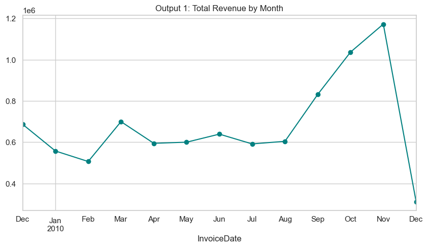

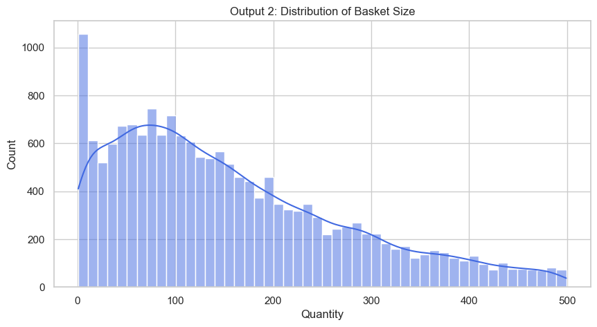

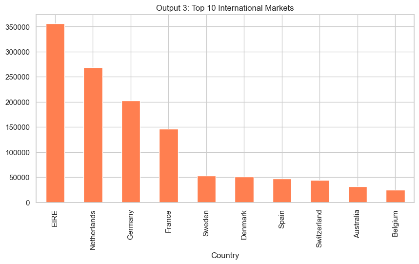

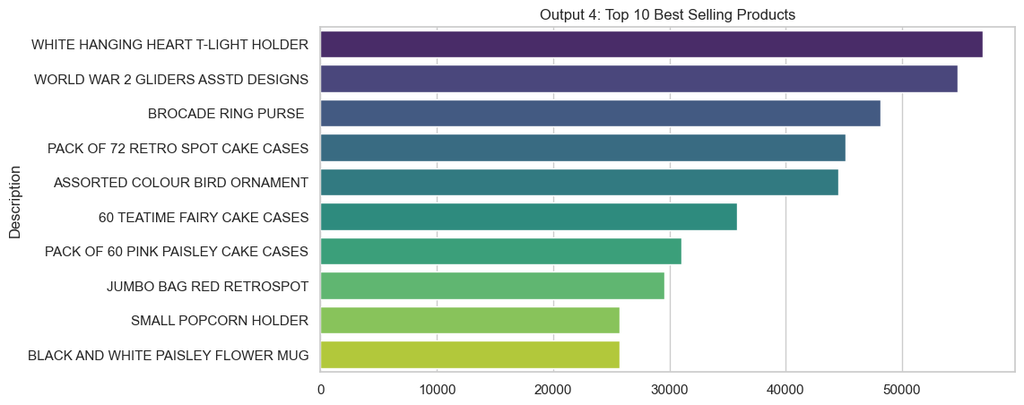

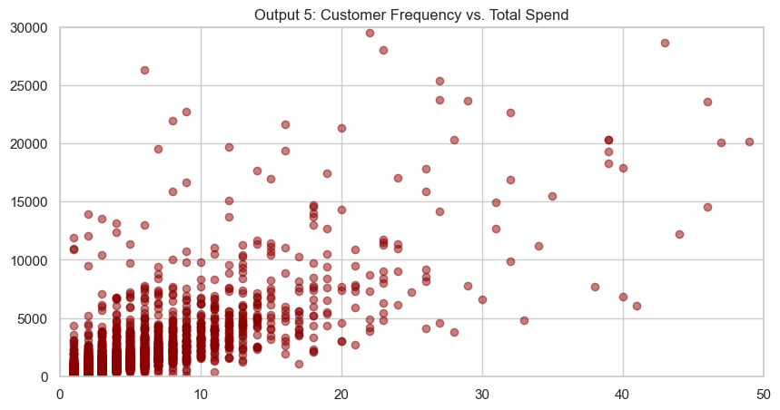

```python
# Task 5 — Exploratory Data Analysis (EDA) Analysis
import matplotlib.pyplot as plt
import seaborn as sns
import pandas as pd

# Fix the Date column - added dayfirst=True to fix the ValueError
df_clean['InvoiceDate'] = pd.to_datetime(df_clean['InvoiceDate'], dayfirst=True)

# Ensure TotalAmount is calculated on the clean data
df_clean['TotalAmount'] = df_clean['Quantity'] * df_clean['Price']

sns.set_theme(style="whitegrid")

# 1. TEMPORAL PATTERN
plt.figure(figsize=(10, 5))
monthly_revenue = df_clean.set_index('InvoiceDate').resample('M')['TotalAmount'].sum()
monthly_revenue.plot(kind='line', marker='o', color='teal')
plt.title('Output 1: Total Revenue by Month')
plt.show()

# 2. TRANSACTIONAL STRUCTURE (Basket Size)
plt.figure(figsize=(10, 5))
basket_size = df_clean.groupby('Invoice')['Quantity'].sum()
sns.histplot(basket_size[basket_size < 500], bins=50, color='royalblue', kde=True)
plt.title('Output 2: Distribution of Basket Size')
plt.show()

# 3. COUNTRY PATTERN
plt.figure(figsize=(10, 5))
top_countries = df_clean[df_clean['Country'] != 'United Kingdom'].groupby('Country')['TotalAmount'].sum().sort_values(ascending=False).head(10)
top_countries.plot(kind='bar', color='coral')
plt.title('Output 3: Top 10 International Markets')
plt.show()

# 4. PRODUCT PATTERN
plt.figure(figsize=(10, 5))
top_products = df_clean.groupby('Description')['Quantity'].sum().sort_values(ascending=False).head(10)
sns.barplot(x=top_products.values, y=top_products.index, palette='viridis')
plt.title('Output 4: Top 10 Best Selling Products')
plt.show()

# 5. CUSTOMER PATTERN
plt.figure(figsize=(10, 5))
customer_data = df_clean.groupby('Customer ID').agg({'Invoice': 'nunique', 'TotalAmount': 'sum'})
plt.scatter(customer_data['Invoice'], customer_data['TotalAmount'], alpha=0.5, color='darkred')
plt.title('Output 5: Customer Frequency vs. Total Spend')
plt.ylim(0, 30000) # Adjusted limits for better visibility
plt.xlim(0, 50)
plt.show()
```

Task 5 — Exploratory Data Analysis (EDA) Analysis

Analyzing what inference can be drawn from the patterns on the data cleaned and visualized would call for a graphical perspective.

Output 1: Total Revenue by Month (Temporal) Question: Does the business experience significant seasonal fluctuations in revenue? Key Pattern: The revenue experiences an enormous increase during the "Golden Quarter" between September and November, with November reaching its highest point at more than £1.1 million. The business depends on Christmas and holiday shopping time for its main revenue source. Limitation: The dataset ends in mid-December 2010, which causes an artificial drop in December 2010 because the dataset stops collecting data, making it seem that demand has decreased.

Output 2: Distribution of Basket Size (Transactional) Question: What is the typical quantity of items purchased in a single transaction? Key Pattern: The distribution is highly right-skewed. While the most frequent "baskets" are very small (0–50 items), there is a long, continuous tail stretching toward 500 items, indicating a mix of small retail and larger wholesale-style orders. Limitation: This chart is capped at 500 items to maintain readability; therefore, it does not reflect the behavior of extreme bulk-buyers who may purchase thousands of items at once.

Output 3: Top 10 International Markets (Country) Question: Which international markets contribute the most revenue outside of the United Kingdom? Key Pattern: EIRE (Ireland) is the dominant international market by a significant margin, generating over £350,000, followed by the Netherlands and Germany. Limitation: The chart displays international performance metrics because it excludes UK data yet this method creates an inaccurate representation of total business revenue since UK revenue accounts for the majority.

Output 5: Frequency vs. Total Spend (Customer) Question: How does the frequency of a customer's visits correlate with their total monetary value? Key Pattern: There is a visible positive correlation; customers who visit more frequently (X-axis) generally trend toward higher lifetime spend (Y-axis). However, there are "high-value outliers" who spend significantly despite having fewer than 20 visits. Limitation: Due to the high number of one-time shoppers, the bottom-left corner of the scatter plot is very dense (overplotted), making it difficult to analyze individual small-customer behaviors.

Task 6 — Reflection and Planning

Three Key Insights from Week 1 Analysis:

1.The business relies heavily on its revenue from the last quarter of the year. The revenue for November reaches almost twice the amount which the business generates during its summer months because customers show peak shopping activity during the Christmas season. 2.The transactional data shows two different customer groups which consist of high-frequency retail shoppers who purchase small quantities and low-frequency bulk buyers who typically order large and expensive items.

3.The business generates its highest revenue outside the United Kingdom from EIRE and the Netherlands. The company has established successful operations in European markets which present opportunities for further improvement.

Two Assumptions or Risks:

1.The Missing ID Assumption shows that I eliminated more than 100000 rows because of absent Customer ID information. The risk exists because "guest" shoppers will behave differently than registered customers which my upcoming models will not include. 2.The process of "Gross Sales" calculation requires me to eliminate negative quantities which represent returns. The current situation allows me to overlook products which need to be returned because they return at a high rate which indicates either quality problems or logistics challenges.

Chosen Unit of Analysis:

I selected the Customer Level for my entire work starting from Week 2. This approach enables me to monitor customer behavior over extended periods instead of tracking their individual product purchases.

Next Modelling Task:

Next week, I plan to explore Customer Segmentation. I will develop an RFM (Recency, Frequency, Monetary) Model to categorize customers into segments which include "Champions," "At Risk," and "Hibernating" using the processed data.